# Coursework Report

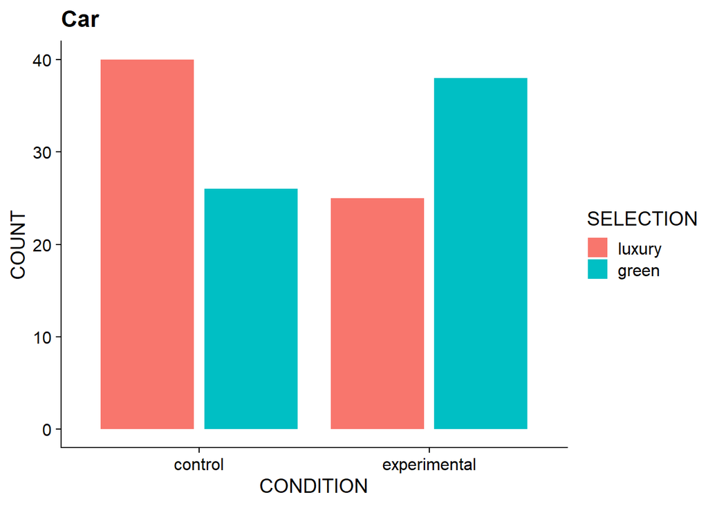

```
## [1] "data.clean %>%\n  ggplot(aes(x == \"cleaner\")) +\n  stat = \"count\") +\n  geom_histogram()"
```

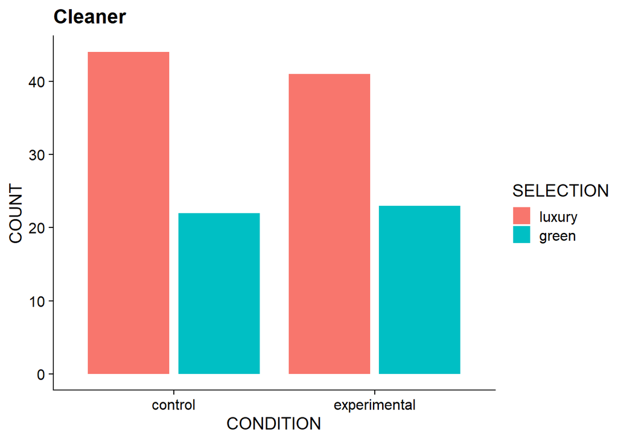

```
## [1] "data.clean %>%\n  ggplot(aes(x == \"dishwasher\")) +\n  stat = \"count\") +\n  geom_histogram()"
```

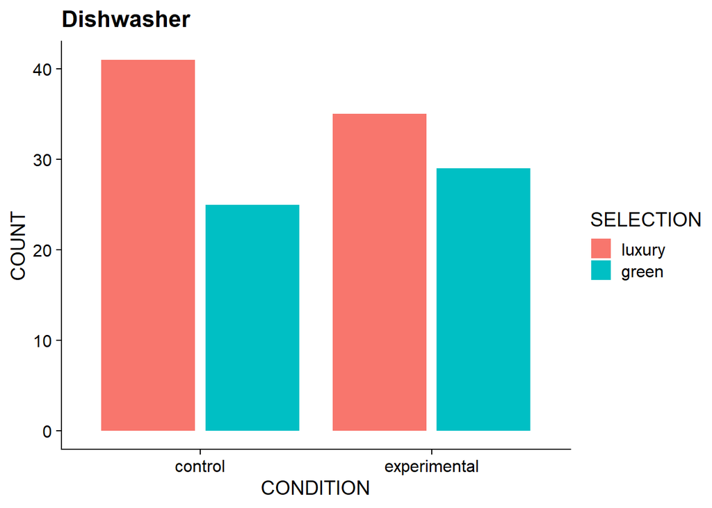

Car Summary Table

|  | control | experimental |
| --- | --- | --- |
| luxury | 40 | 25 |
| green | 26 | 38 |

```
##          CONDITION
## SELECTION control experimental
##    luxury      40           25
##    green       26           38
```

```
##
##  Pearson's Chi-squared test with Yates' continuity correction
##
## data:  car_sum_tab
## X-squared = 5, df = 1, p-value = 0.03
```

Car Expected Frequencies

|  | control | experimental |
| --- | --- | --- |
| luxury | 33.3 | 31.7 |
| green | 32.7 | 31.3 |

Cleaner Summary Table

|  | control | experimental |
| --- | --- | --- |
| luxury | 44 | 41 |
| green | 22 | 23 |

```
##
##  Pearson's Chi-squared test with Yates' continuity correction
##
## data:  cleaner_sum_tab
## X-squared = 0.02, df = 1, p-value = 0.9
```

Cleaner Expected Frequencies

|  | control | experimental |
| --- | --- | --- |
| luxury | 43.1 | 41.9 |
| green | 22.9 | 22.1 |

Dishwasher Summary Table

|  | control | experimental |
| --- | --- | --- |
| luxury | 41 | 35 |
| green | 25 | 29 |

```
##
##  Pearson's Chi-squared test with Yates' continuity correction
##
## data:  dishwasher_sum_tab
## X-squared = 0.5, df = 1, p-value = 0.5
```

Dishwasher Expected Frequencies

|  | control | experimental |
| --- | --- | --- |
| luxury | 38.6 | 37.4 |
| green | 27.4 | 26.6 |

# Methods

## Participants

Initially, the study consisted of 504 participants. 99 participants were removed as they are under 18 years old. 12 participants are removed as their data is not available (NA). 3 participants with the ID_CODE “GPIL” are removed because of their duplication and are aged as two years old. 1 participant is removed because their age 2w is invalid. In total, 115 participants are removed and final participant count is 389 (Mage = 20.76, SDage = 2.01). All participants are randomly selected into their respective conditions

Table 1: Summary of Demographics

| Mean Age | Standard Deviation Age | Minimum Age | Maximum Age |
| --- | --- | --- | --- |
| 20.8 | 2.01 | 18 | 26 |

Table 2: Participant Descriptives

| Gender | Condition | Selection | N |
| --- | --- | --- | --- |
| female | control | luxury | 56 |
| female | control | green | 31 |
| female | experimental | luxury | 48 |
| female | experimental | green | 39 |
| male | control | luxury | 44 |
| male | control | green | 31 |
| male | experimental | luxury | 37 |
| male | experimental | green | 34 |
| other | control | luxury | 25 |
| other | control | green | 11 |
| other | experimental | luxury | 16 |
| other | experimental | green | 17 |

## Design

Presence of status motives would lead people to display more prosocial behaviors.The prediction of the study is therefore, participants in the experimental condition are more likely to choose green products over luxury products compared to those in the control condition. Participants in the experimental condition are given a short story to read in order to elicit status motives. Therefore, the independent variable of the study is presence of status motives. The dependent variable of the study is the engagement in prosocial behaviour. This is operationalized by the likelihood of choosing the green product over the luxury product. Choosing the green product would indicate greater engagement in prosocial behaviour. Chi-squared analyses were performed for each variable to investigate whether engagement in prosocial behaviour was associated with presence of status motives.